# R Notebook

# Principle Component Analysis in R

```r
# Loading required package: psych
require(psych)
# Loading required package: GPArotation
require(GPArotation)
library(lattice)
url <- "/Users/jialincheoh/Desktop/survey_final_read.csv"
survey <- read.csv(url, header=TRUE)
survey
```

| Q2_Q2_1 | Q2_Q2_2 | Q2_Q2_3 | Q2_Q2_4 | Q2_Q2_5 | Q2_Q2_6 | Q2_Q2_7 | Q2_Q2_8 | Q2_Q2_9 | Q2_Q2_10 | Q2_Q2_11 | Q2_Q2_12 | Q2_Q2_13 | Q3_Q3_1 | Q3_Q3_2 | Q3_Q3_3 | Q3_Q3_4 | Q3_Q3_5 | Q4_Q4_1 | Q4_Q4_2 | Q4_Q4_3 | Q4_Q4_4 | Q4_Q4_5 | Q5_Q5_1 | Q5_Q5_2 | Q5_Q5_3 | Q5_Q5_4 | Q5_Q5_5 | Q7_Q7_1 | Q7_Q7_2 | … |
| --- | --- | --- | --- | --- | --- | --- | --- | --- | --- | --- | --- | --- | --- | --- | --- | --- | --- | --- | --- | --- | --- | --- | --- | --- | --- | --- | --- | --- | --- | --- |
| 3 | 5 | 5 | 3 | 4 | 3 | 5 | 5 | 3 | 3 | 3 | 3 | 6 | 4 | 5 | 5 | 5 | 4 | 4 | 4 | 4 | 4 | 4 | 5 | 5 | 4 | 5 | 6 | 4 | 3 | … |
| 2 | 5 | 2 | 2 | 3 | 3 | 5 | 4 | 3 | 4 | 3 | 4 | 5 | 1 | 5 | 3 | 4 | 3 | 3 | 6 | 5 | 3 | 4 | 1 | 1 | 3 | 3 | 4 | 0 | 1 | … |
| 3 | 2 | 6 | 2 | 2 | 2 | 6 | 5 | 3 | 6 | 4 | 6 | 6 | 6 | 5 | 5 | 5 | 4 | 4 | 2 | 4 | 3 | 4 | 3 | 2 | 5 | 3 | 6 | 0 | 2 | … |
| 4 | 4 | 3 | 0 | 0 | 0 | 6 | 6 | 5 | 6 | 0 | 0 | 6 | 3 | 5 | 5 | 6 | 5 | 0 | 0 | 0 | 0 | 0 | 0 | 0 | 4 | 0 | 5 | 0 | 0 | … |
| 1 | 5 | 5 | 2 | 2 | 3 | 5 | 4 | 3 | 4 | 4 | 4 | 6 | 3 | 4 | 3 | 5 | 4 | 6 | 2 | 6 | 3 | 6 | 3 | 3 | 4 | 0 | 4 | 1 | 2 | … |
| 3 | 4 | 4 | 2 | 4 | 2 | 5 | 4 | 5 | 5 | 3 | 4 | 5 | 3 | 4 | 5 | 3 | 5 | 3 | 3 | 2 | 4 | 3 | 3 | 2 | 4 | 2 | 5 | 1 | 2 | … |
| 0 | 2 | 3 | 2 | 2 | 4 | 5 | 5 | 4 | 5 | 1 | 1 | 3 | 3 | 4 | 4 | 4 | 4 | 5 | 5 | 5 | 5 | 5 | 3 | 3 | 4 | 3 | 4 | 1 | 4 | … |
| 4 | 5 | 4 | 3 | 4 | 5 | 5 | 4 | 4 | 5 | 3 | 4 | 4 | 5 | 5 | 4 | 4 | 5 | 5 | 4 | 5 | 4 | 5 | 5 | 4 | 5 | 4 | 5 | 5 | 4 | … |
| 3 | 3 | 6 | 3 | 4 | 5 | 6 | 4 | 5 | 5 | 4 | 4 | 5 | 4 | 6 | 6 | 6 | 5 | 4 | 4 | 5 | 4 | 5 | 3 | 2 | 4 | 3 | 5 | 1 | 2 | … |
| 3 | 6 | 6 | 4 | 5 | 5 | 6 | 6 | 5 | 5 | 5 | 5 | 6 | 4 | 5 | 5 | 4 | 6 | 5 | 4 | 5 | 5 | 6 | 5 | 2 | 5 | 2 | 5 | 1 | 0 | … |

[output cut: 153 more lines]

```r
names(survey)[1:13] <- c("monetary_compensation", "excellent_programmer", "internship",
                         "introduce_ideas", "get_in_touch", "known_creativity", "improve_skills",
                         "test_capability", "enjoy_problems", "keep_up", "dissatisfaction", "curious", "pass_class")
survey
```

| monetary_compensation | excellent_programmer | internship | introduce_ideas | get_in_touch | known_creativity | improve_skills | test_capability | enjoy_problems | keep_up | dissatisfaction | curious | pass_class | Q3_Q3_1 | Q3_Q3_2 | Q3_Q3_3 | Q3_Q3_4 | Q3_Q3_5 | Q4_Q4_1 | Q4_Q4_2 | Q4_Q4_3 | Q4_Q4_4 | Q4_Q4_5 | Q5_Q5_1 | Q5_Q5_2 | Q5_Q5_3 | Q5_Q5_4 | Q5_Q5_5 | Q7_Q7_1 | Q7_Q7_2 | … |
| --- | --- | --- | --- | --- | --- | --- | --- | --- | --- | --- | --- | --- | --- | --- | --- | --- | --- | --- | --- | --- | --- | --- | --- | --- | --- | --- | --- | --- | --- | --- |
| 3 | 5 | 5 | 3 | 4 | 3 | 5 | 5 | 3 | 3 | 3 | 3 | 6 | 4 | 5 | 5 | 5 | 4 | 4 | 4 | 4 | 4 | 4 | 5 | 5 | 4 | 5 | 6 | 4 | 3 | … |
| 2 | 5 | 2 | 2 | 3 | 3 | 5 | 4 | 3 | 4 | 3 | 4 | 5 | 1 | 5 | 3 | 4 | 3 | 3 | 6 | 5 | 3 | 4 | 1 | 1 | 3 | 3 | 4 | 0 | 1 | … |
| 3 | 2 | 6 | 2 | 2 | 2 | 6 | 5 | 3 | 6 | 4 | 6 | 6 | 6 | 5 | 5 | 5 | 4 | 4 | 2 | 4 | 3 | 4 | 3 | 2 | 5 | 3 | 6 | 0 | 2 | … |
| 4 | 4 | 3 | 0 | 0 | 0 | 6 | 6 | 5 | 6 | 0 | 0 | 6 | 3 | 5 | 5 | 6 | 5 | 0 | 0 | 0 | 0 | 0 | 0 | 0 | 4 | 0 | 5 | 0 | 0 | … |
| 1 | 5 | 5 | 2 | 2 | 3 | 5 | 4 | 3 | 4 | 4 | 4 | 6 | 3 | 4 | 3 | 5 | 4 | 6 | 2 | 6 | 3 | 6 | 3 | 3 | 4 | 0 | 4 | 1 | 2 | … |
| 3 | 4 | 4 | 2 | 4 | 2 | 5 | 4 | 5 | 5 | 3 | 4 | 5 | 3 | 4 | 5 | 3 | 5 | 3 | 3 | 2 | 4 | 3 | 3 | 2 | 4 | 2 | 5 | 1 | 2 | … |
| 0 | 2 | 3 | 2 | 2 | 4 | 5 | 5 | 4 | 5 | 1 | 1 | 3 | 3 | 4 | 4 | 4 | 4 | 5 | 5 | 5 | 5 | 5 | 3 | 3 | 4 | 3 | 4 | 1 | 4 | … |
| 4 | 5 | 4 | 3 | 4 | 5 | 5 | 4 | 4 | 5 | 3 | 4 | 4 | 5 | 5 | 4 | 4 | 5 | 5 | 4 | 5 | 4 | 5 | 5 | 4 | 5 | 4 | 5 | 5 | 4 | … |
| 3 | 3 | 6 | 3 | 4 | 5 | 6 | 4 | 5 | 5 | 4 | 4 | 5 | 4 | 6 | 6 | 6 | 5 | 4 | 4 | 5 | 4 | 5 | 3 | 2 | 4 | 3 | 5 | 1 | 2 | … |
| 3 | 6 | 6 | 4 | 5 | 5 | 6 | 6 | 5 | 5 | 5 | 5 | 6 | 4 | 5 | 5 | 4 | 6 | 5 | 4 | 5 | 5 | 6 | 5 | 2 | 5 | 2 | 5 | 1 | 0 | … |

[output cut: 153 more lines]

```r
# Extract all 13 survey items with motivation construct
motivation <- survey[c(1:13)]
motivation
```

| monetary_compensation | excellent_programmer | internship | introduce_ideas | get_in_touch | known_creativity | improve_skills | test_capability | enjoy_problems | keep_up | dissatisfaction | curious | pass_class |
| --- | --- | --- | --- | --- | --- | --- | --- | --- | --- | --- | --- | --- |
| 3 | 5 | 5 | 3 | 4 | 3 | 5 | 5 | 3 | 3 | 3 | 3 | 6 |
| 2 | 5 | 2 | 2 | 3 | 3 | 5 | 4 | 3 | 4 | 3 | 4 | 5 |
| 3 | 2 | 6 | 2 | 2 | 2 | 6 | 5 | 3 | 6 | 4 | 6 | 6 |
| 4 | 4 | 3 | 0 | 0 | 0 | 6 | 6 | 5 | 6 | 0 | 0 | 6 |
| 1 | 5 | 5 | 2 | 2 | 3 | 5 | 4 | 3 | 4 | 4 | 4 | 6 |
| 3 | 4 | 4 | 2 | 4 | 2 | 5 | 4 | 5 | 5 | 3 | 4 | 5 |
| 0 | 2 | 3 | 2 | 2 | 4 | 5 | 5 | 4 | 5 | 1 | 1 | 3 |
| 4 | 5 | 4 | 3 | 4 | 5 | 5 | 4 | 4 | 5 | 3 | 4 | 4 |
| 3 | 3 | 6 | 3 | 4 | 5 | 6 | 4 | 5 | 5 | 4 | 4 | 5 |
| 3 | 6 | 6 | 4 | 5 | 5 | 6 | 6 | 5 | 5 | 5 | 5 | 6 |

[output cut: 153 more lines]

```r
lowerCor(motivation)
```

```
                      mntr_ excl_ intrn intr_ gt_n_ knwn_ impr_ tst_c enjy_ kep_p dssts curis pss_c
monetary_compensation  1.00
excellent_programmer   0.44  1.00
internship             0.32  0.51  1.00
introduce_ideas        0.36  0.50  0.43  1.00
get_in_touch           0.34  0.57  0.54  0.62  1.00
known_creativity       0.34  0.66  0.49  0.50  0.47  1.00
improve_skills         0.30  0.44  0.46  0.23  0.47  0.33  1.00
test_capability        0.33  0.53  0.46  0.42  0.62  0.43  0.67  1.00
enjoy_problems         0.32  0.52  0.49  0.48  0.59  0.52  0.53  0.66  1.00
keep_up                0.32  0.49  0.48  0.41  0.49  0.48  0.60  0.63  0.57  1.00
dissatisfaction        0.23  0.38  0.30  0.56  0.39  0.33  0.29  0.33  0.40  0.38  1.00
curious                0.27  0.37  0.48  0.45  0.47  0.50  0.41  0.42  0.52  0.48  0.33  1.00
pass_class             0.03 -0.01 -0.15 -0.20 -0.20 -0.05 -0.09 -0.07 -0.24 -0.19 -0.13 -0.25  1.00
```

```r
library(correlation)

correlation::correlation(motivation,
                         include_factors = TRUE, method = "auto"
)
```

```
# Correlation Matrix (auto-method)

Parameter1            |           Parameter2 |     r |         95% CI | t(161) |         p
------------------------------------------------------------------------------------------
monetary_compensation | excellent_programmer |  0.44 | [ 0.31,  0.56] |   6.22 | < .001***
monetary_compensation |           internship |  0.32 | [ 0.18,  0.46] |   4.36 | < .001***
monetary_compensation |      introduce_ideas |  0.36 | [ 0.22,  0.49] |   4.96 | < .001***
monetary_compensation |         get_in_touch |  0.34 | [ 0.20,  0.47] |   4.62 | < .001***
monetary_compensation |     known_creativity |  0.34 | [ 0.19,  0.47] |   4.56 | < .001***
monetary_compensation |       improve_skills |  0.30 | [ 0.15,  0.43] |   4.01 | 0.002**
monetary_compensation |      test_capability |  0.33 | [ 0.18,  0.46] |   4.38 | < .001***
monetary_compensation |       enjoy_problems |  0.32 | [ 0.18,  0.45] |   4.32 | < .001***
monetary_compensation |              keep_up |  0.32 | [ 0.18,  0.45] |   4.33 | < .001***
monetary_compensation |      dissatisfaction |  0.23 | [ 0.08,  0.37] |   2.96 | 0.042*
monetary_compensation |              curious |  0.27 | [ 0.12,  0.40] |   3.51 | 0.009**
monetary_compensation |           pass_class |  0.03 | [-0.13,  0.18] |   0.37 | > .999
excellent_programmer  |           internship |  0.51 | [ 0.39,  0.62] |   7.61 | < .001***
excellent_programmer  |      introduce_ideas |  0.50 | [ 0.37,  0.61] |   7.31 | < .001***
excellent_programmer  |         get_in_touch |  0.57 | [ 0.46,  0.67] |   8.81 | < .001***
excellent_programmer  |     known_creativity |  0.66 | [ 0.56,  0.74] |  11.05 | < .001***
excellent_programmer  |       improve_skills |  0.44 | [ 0.31,  0.56] |   6.22 | < .001***
excellent_programmer  |      test_capability |  0.53 | [ 0.41,  0.63] |   7.95 | < .001***
excellent_programmer  |       enjoy_problems |  0.52 | [ 0.40,  0.62] |   7.68 | < .001***
excellent_programmer  |              keep_up |  0.49 | [ 0.36,  0.60] |   7.10 | < .001***
excellent_programmer  |      dissatisfaction |  0.38 | [ 0.24,  0.51] |   5.24 | < .001***
excellent_programmer  |              curious |  0.37 | [ 0.23,  0.50] |   5.11 | < .001***
excellent_programmer  |           pass_class | -0.01 | [-0.17,  0.14] |  -0.17 | > .999
internship            |      introduce_ideas |  0.43 | [ 0.29,  0.54] |   5.97 | < .001***
internship            |         get_in_touch |  0.54 | [ 0.42,  0.64] |   8.14 | < .001***
internship            |     known_creativity |  0.49 | [ 0.37,  0.60] |   7.18 | < .001***
internship            |       improve_skills |  0.46 | [ 0.33,  0.57] |   6.60 | < .001***
internship            |      test_capability |  0.46 | [ 0.33,  0.57] |   6.52 | < .001***
internship            |       enjoy_problems |  0.49 | [ 0.36,  0.60] |   7.11 | < .001***
internship            |              keep_up |  0.48 | [ 0.35,  0.59] |   6.95 | < .001***
internship            |      dissatisfaction |  0.30 | [ 0.16,  0.44] |   4.02 | 0.002**
internship            |              curious |  0.48 | [ 0.35,  0.59] |   6.93 | < .001***
internship            |           pass_class | -0.15 | [-0.30,  0.00] |  -1.96 | 0.364
introduce_ideas       |         get_in_touch |  0.62 | [ 0.52,  0.71] |  10.15 | < .001***
introduce_ideas       |     known_creativity |  0.50 | [ 0.38,  0.61] |   7.37 | < .001***
introduce_ideas       |       improve_skills |  0.23 | [ 0.08,  0.37] |   2.96 | 0.042*
```

[output cut: 30 more lines]

```
test_capability       |              curious |  0.42 | [ 0.29,  0.54] |   5.91 | < .001***
test_capability       |           pass_class | -0.07 | [-0.23,  0.08] |  -0.94 | > .999
enjoy_problems        |              keep_up |  0.57 | [ 0.46,  0.67] |   8.91 | < .001***
enjoy_problems        |      dissatisfaction |  0.40 | [ 0.26,  0.52] |   5.55 | < .001***
enjoy_problems        |              curious |  0.52 | [ 0.40,  0.62] |   7.69 | < .001***
enjoy_problems        |           pass_class | -0.24 | [-0.38, -0.09] |  -3.09 | 0.030*
keep_up               |      dissatisfaction |  0.38 | [ 0.24,  0.50] |   5.17 | < .001***
keep_up               |              curious |  0.48 | [ 0.35,  0.59] |   6.89 | < .001***
keep_up               |           pass_class | -0.19 | [-0.34, -0.04] |  -2.51 | 0.104
dissatisfaction       |              curious |  0.33 | [ 0.19,  0.46] |   4.44 | < .001***
dissatisfaction       |           pass_class | -0.13 | [-0.28,  0.02] |  -1.67 | 0.587
curious               |           pass_class | -0.25 | [-0.39, -0.10] |  -3.26 | 0.019*

p-value adjustment method: Holm (1979)
Observations: 163
```

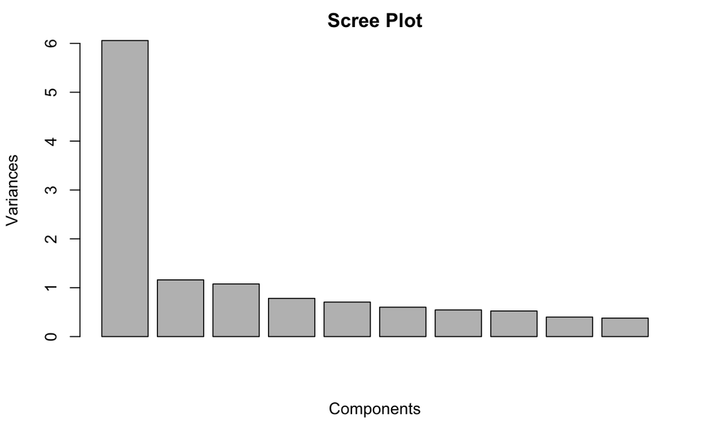

```r
# Do the PCA with singular value decomposition of the (centered and possibly scaled) data matrix

my.prc = prcomp(motivation, center=TRUE, scale=TRUE)
screeplot(my.prc, main="Scree Plot", xlab="Components")
```

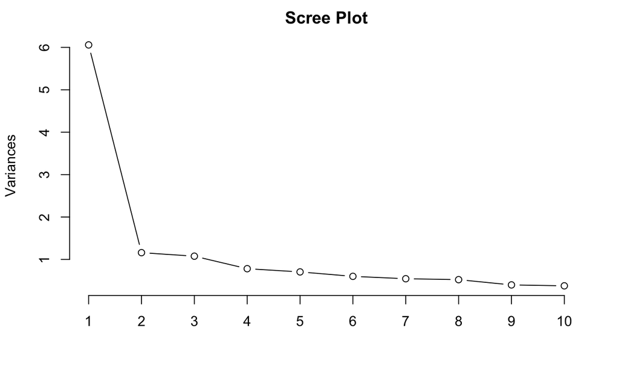

```r
screeplot(my.prc, main="Scree Plot", type="line" )
```

```r
my.prc
```

```
Standard deviations (1, .., p=13):
 [1] 2.4613684 1.0770280 1.0376502 0.8841695 0.8401308 0.7753443 0.7383151 0.7234173 0.6320162 0.6147636 0.5283085 0.5008034 0.4903973

Rotation (n x k) = (13 x 13):
                              PC1         PC2         PC3         PC4          PC5         PC6         PC7         PC8          PC9
monetary_compensation -0.20805591 -0.35365688  0.22255393 -0.18312804  0.827718998 -0.18100739  0.01549168 -0.06466179  0.064168743
excellent_programmer  -0.30707515 -0.26683661  0.18322479 -0.12910614 -0.114888052  0.23469791  0.30607995  0.26467438  0.156264524
internship            -0.28771325 -0.01276108 -0.03483802 -0.34437563 -0.112414258  0.03293788 -0.58607294  0.54902769  0.049546894
introduce_ideas       -0.28621817  0.17279349  0.47466811  0.16531987  0.032064564  0.16284508 -0.12000697 -0.19076830 -0.355424864
get_in_touch          -0.32085074  0.06750616  0.05639089  0.05539077  0.011581991  0.51328409 -0.30981060 -0.20780962 -0.125755454
known_creativity      -0.28992300 -0.13106118  0.24048892 -0.36605736 -0.375570130 -0.08539658  0.42470902  0.01485676  0.008907234
improve_skills        -0.27551172 -0.14423666 -0.52120873  0.18186687  0.082362348 -0.13711392 -0.08636324  0.16650418  0.127028055
test_capability       -0.31565526 -0.13134638 -0.33358991  0.24620001 -0.001415127  0.24224932  0.03398103 -0.22806145 -0.022057810
enjoy_problems        -0.32205629  0.09260449 -0.15064543  0.05319396 -0.036285449  0.09354016  0.18844482 -0.28242653  0.529222251
keep_up               -0.30698844  0.01155401 -0.27622348  0.09654311  0.017345974 -0.24627855  0.29165654  0.16488919 -0.677746632
dissatisfaction       -0.23078015  0.17238455  0.36716647  0.64518255 -0.054292728 -0.36409617 -0.03249928  0.28972145  0.253191648
curious               -0.27494812  0.22501232 -0.03241572 -0.31161151 -0.154521917 -0.55807307 -0.26276906 -0.47224542  0.029513910
pass_class             0.09140153 -0.79047981  0.10753529  0.21817869 -0.334068902 -0.15131832 -0.26933150 -0.22559632 -0.075972531
                             PC10        PC11        PC12        PC13
monetary_compensation -0.05571641  0.03159581  0.09740723 -0.09252813
excellent_programmer   0.37530598 -0.49429179 -0.35672744  0.12406248
internship            -0.33989069  0.03326919 -0.09219204 -0.10501628
introduce_ideas       -0.07323229  0.34688382 -0.44714677  0.32447158
get_in_touch           0.23877317 -0.18507341  0.61263068  0.03304425
known_creativity       0.01842609  0.49284522  0.32477753 -0.17086552
improve_skills         0.41942571  0.42273196 -0.00247409  0.40868871
test_capability       -0.03632943  0.11800885 -0.32288567 -0.69236704
enjoy_problems        -0.57557316 -0.11111109  0.03333921  0.33469402
keep_up               -0.27206929 -0.29018257  0.13788470  0.10108570
dissatisfaction        0.04924476 -0.07027253  0.17854635 -0.20517267
curious                0.26478240 -0.23974084 -0.12645871 -0.06153314
pass_class            -0.15073693 -0.06707934  0.04201664  0.12219140
```

```r
# Kaiser criterion to determine the number of principle components to keep
my.prc$sdev ^ 2
```

```
 [1] 6.0583344 1.1599892 1.0767180 0.7817557 0.7058198 0.6011588 0.5451092 0.5233326 0.3994445 0.3779343 0.2791099 0.2508041 0.2404895
```

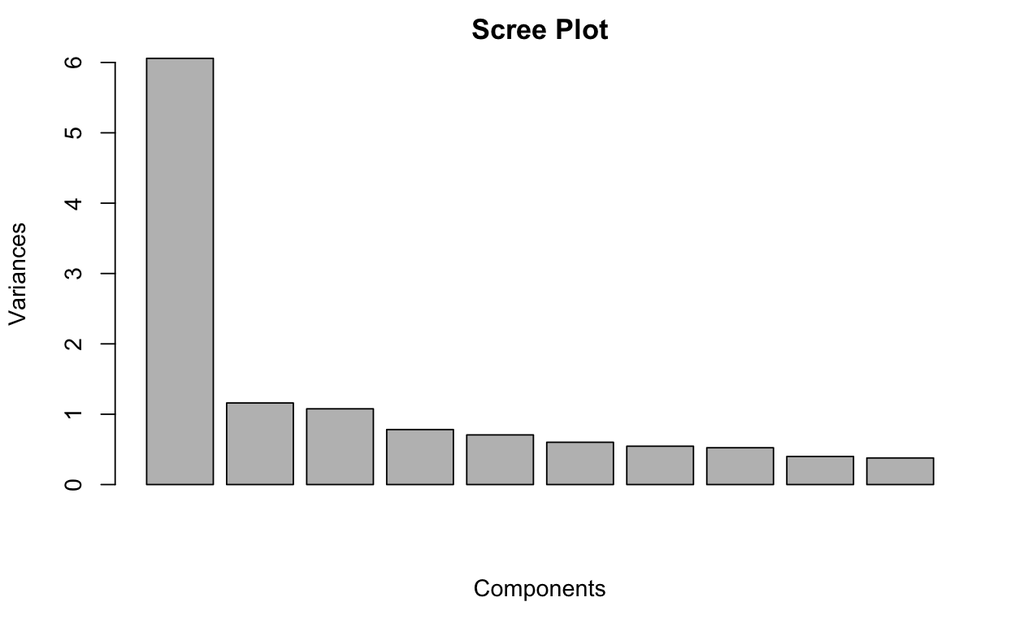

```r
screeplot(my.prc, main="Scree Plot", xlab="Components")
```

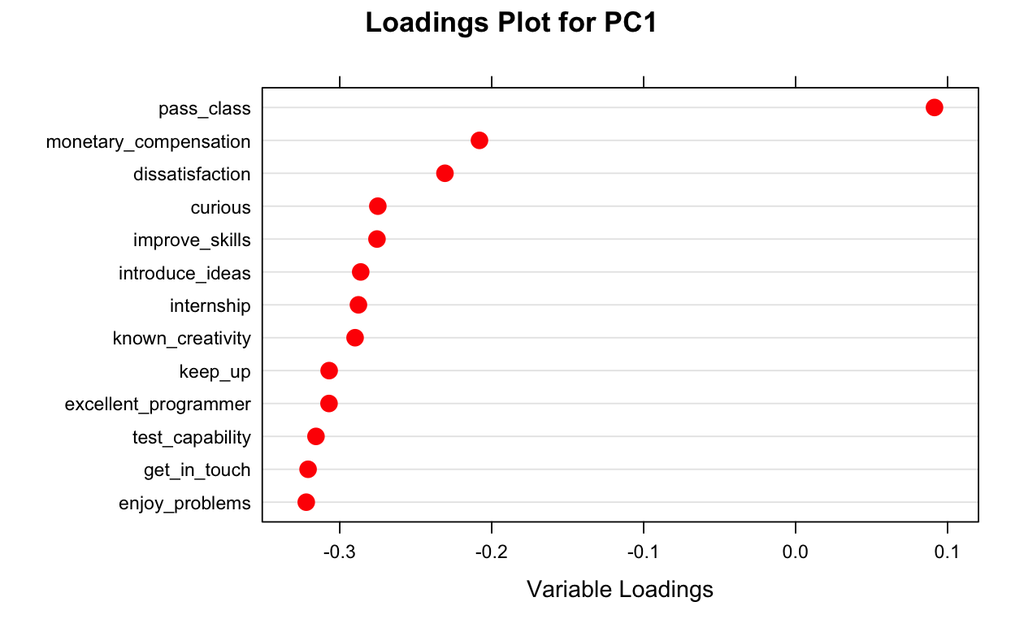

```r
# DotPlot PC1

load    <- my.prc$rotation
sorted.loadings <- load[order(load[, 1]), 1]
myTitle <- "Loadings Plot for PC1"
myXlab  <- "Variable Loadings"
dotplot(sorted.loadings, main=myTitle, xlab=myXlab, cex=1.5, col="red")
```

```r
summary(my.prc)
```

```
Importance of components:
                         PC1     PC2     PC3     PC4     PC5     PC6     PC7     PC8     PC9    PC10    PC11    PC12   PC13
Standard deviation     2.461 1.07703 1.03765 0.88417 0.84013 0.77534 0.73832 0.72342 0.63202 0.61476 0.52831 0.50080 0.4904
Proportion of Variance 0.466 0.08923 0.08282 0.06014 0.05429 0.04624 0.04193 0.04026 0.03073 0.02907 0.02147 0.01929 0.0185
Cumulative Proportion  0.466 0.55526 0.63808 0.69822 0.75251 0.79875 0.84068 0.88094 0.91167 0.94074 0.96221 0.98150 1.0000
```

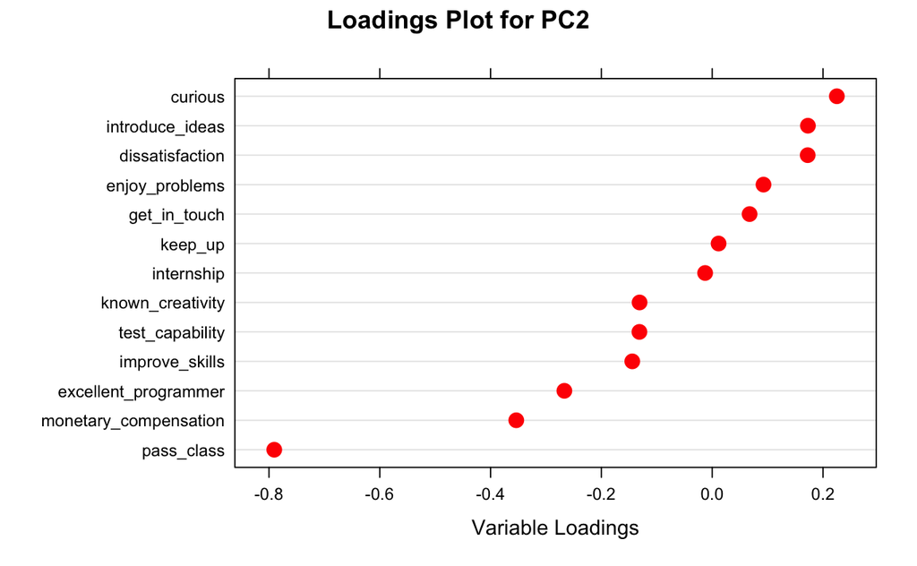

```r
# DotPlot PC2

sorted.loadings <- load[order(load[, 2]), 2]
myTitle <- "Loadings Plot for PC2"
myXlab  <- "Variable Loadings"
dotplot(sorted.loadings, main=myTitle, xlab=myXlab, cex=1.5, col="red")
```

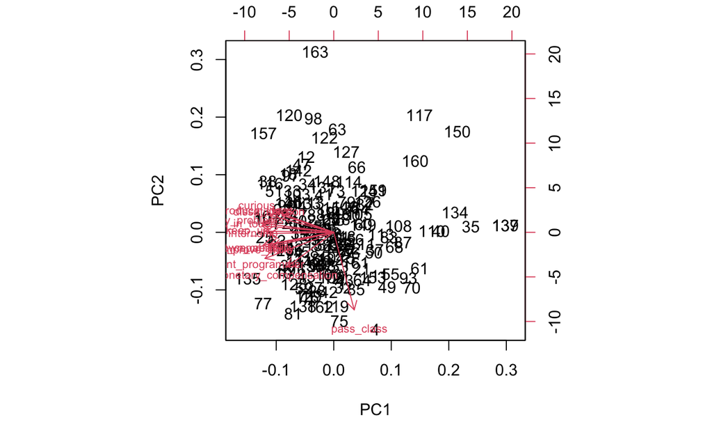

```r
# Now draw the BiPlot
biplot(my.prc, cex=c(1, 0.7))
```

```r
my.prc$rotation[, 1:2]
```

```
                              PC1         PC2
monetary_compensation -0.20805591 -0.35365688
excellent_programmer  -0.30707515 -0.26683661
internship            -0.28771325 -0.01276108
introduce_ideas       -0.28621817  0.17279349
get_in_touch          -0.32085074  0.06750616
known_creativity      -0.28992300 -0.13106118
improve_skills        -0.27551172 -0.14423666
test_capability       -0.31565526 -0.13134638
enjoy_problems        -0.32205629  0.09260449
keep_up               -0.30698844  0.01155401
dissatisfaction       -0.23078015  0.17238455
curious               -0.27494812  0.22501232
pass_class             0.09140153 -0.79047981
```

```r
options(max.print=1000000)
project.b = predict(my.prc, motivation)
project.b
```

```
                PC1         PC2          PC3         PC4          PC5          PC6          PC7          PC8          PC9         PC10
  [1,]  0.457301629 -1.21898165  0.337972407  0.28806271 -0.099172156  0.792753136 -1.002920302  0.374488650  0.351377827  0.500005678
  [2,]  1.260492158 -0.37996942 -0.124743003  0.46185381 -0.296700782 -0.255169387  0.569265817 -0.282264866  0.078206445  1.171980411
  [3,]  0.023172528 -0.30428466 -1.483086016  0.52413558  0.031421819 -2.436944650 -1.772927975  0.276656638 -0.811432437 -0.455923687
  [4,]  2.266011345 -2.31450555 -3.269700765  1.07544902  1.789948191  0.519583656  1.196027837  0.725424761 -0.108149597 -1.630327707
  [5,]  0.952246887 -0.61732266 -0.065438500  0.41596533 -1.260167089 -0.732494031 -0.552572077  0.982519904  0.325917448  0.338959313
  [6,]  0.285218145 -0.16104414 -0.709866626  0.43446593  0.366113287 -0.154337718 -0.379390314 -0.201088710  0.192466758 -0.411591010
  [7,]  2.009366194  0.71068413 -1.738040034  0.29987988 -0.609459685  0.990541227  1.362434565  0.435661743 -0.656020141 -0.934097727
  [8,] -0.660619552 -0.28889388  0.380075571 -0.58965686  0.262575227 -0.152285357  0.676960720  0.182615219 -0.186602284  0.288107903
  [9,] -1.020713876 -0.16921357 -0.264372224 -0.02684385 -0.427951474 -0.680329717 -0.615880379  0.547890766  0.206084920 -0.740507823
 [10,] -2.759190381 -0.96893099  0.224879335  0.53256284 -0.982097823 -0.139730739 -0.597957462  0.204724459  0.315537930  0.187464612
 [11,]  2.489235859 -1.03333903  0.189250369 -1.57113116  0.090151065  1.466831634 -0.184488589  0.095045140  0.676880232  0.318606511
 [12,] -1.501530183  1.80765136 -2.026096681 -0.73196223  1.647060063 -2.134403457  1.102691293  0.388235827  1.015886760 -0.791968954
 [13,] -1.005151499  0.71231472  1.401958108  0.29761952  0.403677053 -0.259247890  1.301061871 -0.112104027  0.186752493 -0.115143265
 [14,]  1.481870722  0.54515169  0.288992418 -0.08677320 -1.947658487 -2.102204180  0.270172208  0.459571626  0.080913283  0.068053638
```

[output cut: 313 more lines]

## Done varimax rotation on 6 components.

```r
# Apply the Varimax Rotation
my.var <- varimax(my.prc$rotation[, 1:6])

my.var
```

```
$loadings

Loadings:
                      PC1    PC2    PC3    PC4    PC5    PC6
monetary_compensation                              0.984
excellent_programmer         -0.203        -0.324         0.358
internship                          -0.127 -0.423
introduce_ideas        0.173  0.113  0.477 -0.102         0.325
get_in_touch                  0.129                       0.593
known_creativity       0.101 -0.148        -0.635
improve_skills        -0.635        -0.104
test_capability       -0.455                              0.348
enjoy_problems        -0.282  0.121        -0.108         0.189
keep_up               -0.459                             -0.120
dissatisfaction       -0.123         0.843  0.145        -0.113
curious               -0.185  0.212  0.136 -0.493        -0.467
pass_class                   -0.906

                 PC1   PC2   PC3   PC4   PC5   PC6
SS loadings    1.000 1.000 1.000 1.000 1.000 1.000
Proportion Var 0.077 0.077 0.077 0.077 0.077 0.077
Cumulative Var 0.077 0.154 0.231 0.308 0.385 0.462

$rotmat
           [,1]        [,2]       [,3]        [,4]       [,5]        [,6]
[1,]  0.5830932 -0.12087769 -0.3610033  0.56174798 -0.2090175 -0.39473841
[2,]  0.0847261  0.88186043  0.2646254  0.06534396 -0.3609462 -0.10278652
[3,]  0.7182270 -0.11943813  0.5935219 -0.21297779  0.2375212  0.12585915
[4,] -0.2959732 -0.26334281  0.5910278  0.65720511 -0.2019046  0.14509508
[5,] -0.0497057  0.33934870 -0.0632733  0.41996604  0.8371249  0.03491037
[6,]  0.2165711  0.09454269 -0.3066993  0.16284902 -0.1675401  0.89191069
```

## Interpretation:

> Assume threshold 0.5

```r
# Apply the Varimax Rotation
my.var <- varimax(my.prc$rotation[, 1:2])

my.var
```

```
$loadings

Loadings:
                      PC1    PC2
monetary_compensation        -0.403
excellent_programmer         -0.403
internship            -0.209 -0.198
introduce_ideas       -0.329
get_in_touch          -0.286 -0.160
known_creativity      -0.133 -0.289
improve_skills        -0.113 -0.290
test_capability       -0.152 -0.306
enjoy_problems        -0.304 -0.142
keep_up               -0.239 -0.193
dissatisfaction       -0.287
curious               -0.355
pass_class             0.588 -0.536

                 PC1   PC2
SS loadings    1.000 1.000
Proportion Var 0.077 0.077
Cumulative Var 0.077 0.154

$rotmat
           [,1]      [,2]
[1,]  0.7543800 0.6564379
[2,] -0.6564379 0.7543800
```

```r
# Apply the Varimax Rotation
my.var <- varimax(my.prc$rotation[, 1:3])

my.var
```

```
$loadings

Loadings:
                      PC1    PC2    PC3
monetary_compensation        -0.457
excellent_programmer  -0.115 -0.399  0.164
internship            -0.242         0.132
introduce_ideas              -0.117  0.562
get_in_touch          -0.209         0.251
known_creativity             -0.296  0.259
improve_skills        -0.546        -0.263
test_capability       -0.456        -0.109
enjoy_problems        -0.344         0.126
keep_up               -0.413
dissatisfaction                      0.459
curious               -0.232  0.120  0.243
pass_class             0.143 -0.700 -0.366

                 PC1   PC2   PC3
SS loadings    1.000 1.000 1.000
Proportion Var 0.077 0.077 0.077
Cumulative Var 0.077 0.154 0.231

$rotmat
             [,1]       [,2]       [,3]
[1,]  0.763035991  0.3192797 -0.5619934
[2,] -0.004607316  0.8721442  0.4892271
[3,]  0.646339578 -0.3707086  0.6669485
```

```r
head(my.prc$x)
```

```
            PC1        PC2        PC3       PC4         PC5        PC6        PC7        PC8         PC9       PC10        PC11
[1,] 0.45730163 -1.2189817  0.3379724 0.2880627 -0.09917216  0.7927531 -1.0029203  0.3744886  0.35137783  0.5000057 -0.04510203
[2,] 1.26049216 -0.3799694 -0.1247430 0.4618538 -0.29670078 -0.2551694  0.5692658 -0.2822649  0.07820644  1.1719804 -0.66446856
[3,] 0.02317253 -0.3042847 -1.4830860 0.5241356  0.03142182 -2.4369446 -1.7729280  0.2766566 -0.81143244 -0.4559237 -0.24339690
[4,] 2.26601135 -2.3145055 -3.2697008 1.0754490  1.78994819  0.5195837  1.1960278  0.7254248 -0.10814960 -1.6303277 -0.71347375
[5,] 0.95224689 -0.6173227 -0.0654385 0.4159653 -1.26016709 -0.7324940 -0.5525721  0.9825199  0.32591745  0.3389593 -0.58710369
[6,] 0.28521815 -0.1610441 -0.7098666 0.4344659  0.36611329 -0.1543377 -0.3793903 -0.2010887  0.19246676 -0.4115910 -1.11046226
           PC12        PC13
[1,] -0.5805051 -0.35777127
[2,] -0.3463504  0.13772643
[3,] -0.4861506 -0.49847529
[4,] -1.5028883  0.32901825
[5,] -0.8355245 -0.08118654
[6,]  0.1529842  0.54420657
```

```r
summary(my.prc)
```

```
Importance of components:
                         PC1     PC2     PC3     PC4     PC5     PC6     PC7     PC8     PC9    PC10    PC11    PC12   PC13
Standard deviation     2.461 1.07703 1.03765 0.88417 0.84013 0.77534 0.73832 0.72342 0.63202 0.61476 0.52831 0.50080 0.4904
Proportion of Variance 0.466 0.08923 0.08282 0.06014 0.05429 0.04624 0.04193 0.04026 0.03073 0.02907 0.02147 0.01929 0.0185
Cumulative Proportion  0.466 0.55526 0.63808 0.69822 0.75251 0.79875 0.84068 0.88094 0.91167 0.94074 0.96221 0.98150 1.0000
```

## Get the PCA scores for 163 participants

```r
pca <- predict(my.prc, newdata=motivation)
pca
```

```
                PC1         PC2          PC3         PC4          PC5          PC6          PC7          PC8          PC9         PC10
  [1,]  0.457301629 -1.21898165  0.337972407  0.28806271 -0.099172156  0.792753136 -1.002920302  0.374488650  0.351377827  0.500005678
  [2,]  1.260492158 -0.37996942 -0.124743003  0.46185381 -0.296700782 -0.255169387  0.569265817 -0.282264866  0.078206445  1.171980411
  [3,]  0.023172528 -0.30428466 -1.483086016  0.52413558  0.031421819 -2.436944650 -1.772927975  0.276656638 -0.811432437 -0.455923687
  [4,]  2.266011345 -2.31450555 -3.269700765  1.07544902  1.789948191  0.519583656  1.196027837  0.725424761 -0.108149597 -1.630327707
  [5,]  0.952246887 -0.61732266 -0.065438500  0.41596533 -1.260167089 -0.732494031 -0.552572077  0.982519904  0.325917448  0.338959313
  [6,]  0.285218145 -0.16104414 -0.709866626  0.43446593  0.366113287 -0.154337718 -0.379390314 -0.201088710  0.192466758 -0.411591010
  [7,]  2.009366194  0.71068413 -1.738040034  0.29987988 -0.609459685  0.990541227  1.362434565  0.435661743 -0.656020141 -0.934097727
  [8,] -0.660619552 -0.28889388  0.380075571 -0.58965686  0.262575227 -0.152285357  0.676960720  0.182615219 -0.186602284  0.288107903
  [9,] -1.020713876 -0.16921357 -0.264372224 -0.02684385 -0.427951474 -0.680329717 -0.615880379  0.547890766  0.206084920 -0.740507823
 [10,] -2.759190381 -0.96893099  0.224879335  0.53256284 -0.982097823 -0.139730739 -0.597957462  0.204724459  0.315537930  0.187464612
 [11,]  2.489235859 -1.03333903  0.189250369 -1.57113116  0.090151065  1.466831634 -0.184488589  0.095045140  0.676880232  0.318606511
 [12,] -1.501530183  1.80765136 -2.026096681 -0.73196223  1.647060063 -2.134403457  1.102691293  0.388235827  1.015886760 -0.791968954
 [13,] -1.005151499  0.71231472  1.401958108  0.29761952  0.403677053 -0.259247890  1.301061871 -0.112104027  0.186752493 -0.115143265
 [14,]  1.481870722  0.54515169  0.288992418 -0.08677320 -1.947658487 -2.102204180  0.270172208  0.459571626  0.080913283  0.068053638
```

[output cut: 313 more lines]

```r
print(my.prc)
```

```
Standard deviations (1, .., p=13):
 [1] 2.4613684 1.0770280 1.0376502 0.8841695 0.8401308 0.7753443 0.7383151 0.7234173 0.6320162 0.6147636 0.5283085 0.5008034 0.4903973

Rotation (n x k) = (13 x 13):
                              PC1         PC2         PC3         PC4          PC5         PC6         PC7         PC8          PC9
monetary_compensation -0.20805591 -0.35365688  0.22255393 -0.18312804  0.827718998 -0.18100739  0.01549168 -0.06466179  0.064168743
excellent_programmer  -0.30707515 -0.26683661  0.18322479 -0.12910614 -0.114888052  0.23469791  0.30607995  0.26467438  0.156264524
internship            -0.28771325 -0.01276108 -0.03483802 -0.34437563 -0.112414258  0.03293788 -0.58607294  0.54902769  0.049546894
introduce_ideas       -0.28621817  0.17279349  0.47466811  0.16531987  0.032064564  0.16284508 -0.12000697 -0.19076830 -0.355424864
get_in_touch          -0.32085074  0.06750616  0.05639089  0.05539077  0.011581991  0.51328409 -0.30981060 -0.20780962 -0.125755454
known_creativity      -0.28992300 -0.13106118  0.24048892 -0.36605736 -0.375570130 -0.08539658  0.42470902  0.01485676  0.008907234
improve_skills        -0.27551172 -0.14423666 -0.52120873  0.18186687  0.082362348 -0.13711392 -0.08636324  0.16650418  0.127028055
test_capability       -0.31565526 -0.13134638 -0.33358991  0.24620001 -0.001415127  0.24224932  0.03398103 -0.22806145 -0.022057810
enjoy_problems        -0.32205629  0.09260449 -0.15064543  0.05319396 -0.036285449  0.09354016  0.18844482 -0.28242653  0.529222251
keep_up               -0.30698844  0.01155401 -0.27622348  0.09654311  0.017345974 -0.24627855  0.29165654  0.16488919 -0.677746632
dissatisfaction       -0.23078015  0.17238455  0.36716647  0.64518255 -0.054292728 -0.36409617 -0.03249928  0.28972145  0.253191648
curious               -0.27494812  0.22501232 -0.03241572 -0.31161151 -0.154521917 -0.55807307 -0.26276906 -0.47224542  0.029513910
pass_class             0.09140153 -0.79047981  0.10753529  0.21817869 -0.334068902 -0.15131832 -0.26933150 -0.22559632 -0.075972531
                             PC10        PC11        PC12        PC13
monetary_compensation -0.05571641  0.03159581  0.09740723 -0.09252813
excellent_programmer   0.37530598 -0.49429179 -0.35672744  0.12406248
internship            -0.33989069  0.03326919 -0.09219204 -0.10501628
introduce_ideas       -0.07323229  0.34688382 -0.44714677  0.32447158
get_in_touch           0.23877317 -0.18507341  0.61263068  0.03304425
known_creativity       0.01842609  0.49284522  0.32477753 -0.17086552
improve_skills         0.41942571  0.42273196 -0.00247409  0.40868871
test_capability       -0.03632943  0.11800885 -0.32288567 -0.69236704
enjoy_problems        -0.57557316 -0.11111109  0.03333921  0.33469402
keep_up               -0.27206929 -0.29018257  0.13788470  0.10108570
dissatisfaction        0.04924476 -0.07027253  0.17854635 -0.20517267
curious                0.26478240 -0.23974084 -0.12645871 -0.06153314
pass_class            -0.15073693 -0.06707934  0.04201664  0.12219140
```

```r
summary(motivation)
```

```
 monetary_compensation excellent_programmer   internship    introduce_ideas  get_in_touch   known_creativity improve_skills
 Min.   :0.000         Min.   :0.000        Min.   :0.000   Min.   :0.000   Min.   :0.000   Min.   :0.000    Min.   :0.000
 1st Qu.:2.000         1st Qu.:3.000        1st Qu.:3.000   1st Qu.:2.000   1st Qu.:3.000   1st Qu.:3.000    1st Qu.:4.500
 Median :3.000         Median :4.000        Median :4.000   Median :3.000   Median :4.000   Median :4.000    Median :5.000
 Mean   :2.896         Mean   :4.061        Mean   :4.153   Mean   :2.988   Mean   :3.748   Mean   :3.847    Mean   :4.939
 3rd Qu.:4.000         3rd Qu.:5.000        3rd Qu.:5.000   3rd Qu.:4.000   3rd Qu.:5.000   3rd Qu.:5.000    3rd Qu.:6.000
 Max.   :6.000         Max.   :6.000        Max.   :6.000   Max.   :6.000   Max.   :6.000   Max.   :6.000    Max.   :6.000
 test_capability enjoy_problems     keep_up      dissatisfaction    curious        pass_class
 Min.   :0.00    Min.   :0.000   Min.   :0.000   Min.   :0.000   Min.   :0.000   Min.   :0.000
 1st Qu.:4.00    1st Qu.:3.000   1st Qu.:4.000   1st Qu.:2.000   1st Qu.:3.000   1st Qu.:3.500
 Median :5.00    Median :4.000   Median :5.000   Median :3.000   Median :4.000   Median :5.000
 Mean   :4.38    Mean   :4.086   Mean   :4.448   Mean   :3.098   Mean   :3.847   Mean   :4.331
 3rd Qu.:5.00    3rd Qu.:5.000   3rd Qu.:5.000   3rd Qu.:4.000   3rd Qu.:5.000   3rd Qu.:6.000
 Max.   :6.00    Max.   :6.000   Max.   :6.000   Max.   :6.000   Max.   :6.000   Max.   :6.000
```

```r
head(my.prc$x)
```

```
            PC1        PC2        PC3       PC4         PC5        PC6        PC7        PC8         PC9       PC10        PC11
[1,] 0.45730163 -1.2189817  0.3379724 0.2880627 -0.09917216  0.7927531 -1.0029203  0.3744886  0.35137783  0.5000057 -0.04510203
[2,] 1.26049216 -0.3799694 -0.1247430 0.4618538 -0.29670078 -0.2551694  0.5692658 -0.2822649  0.07820644  1.1719804 -0.66446856
[3,] 0.02317253 -0.3042847 -1.4830860 0.5241356  0.03142182 -2.4369446 -1.7729280  0.2766566 -0.81143244 -0.4559237 -0.24339690
[4,] 2.26601135 -2.3145055 -3.2697008 1.0754490  1.78994819  0.5195837  1.1960278  0.7254248 -0.10814960 -1.6303277 -0.71347375
[5,] 0.95224689 -0.6173227 -0.0654385 0.4159653 -1.26016709 -0.7324940 -0.5525721  0.9825199  0.32591745  0.3389593 -0.58710369
[6,] 0.28521815 -0.1610441 -0.7098666 0.4344659  0.36611329 -0.1543377 -0.3793903 -0.2010887  0.19246676 -0.4115910 -1.11046226
           PC12        PC13
[1,] -0.5805051 -0.35777127
[2,] -0.3463504  0.13772643
[3,] -0.4861506 -0.49847529
[4,] -1.5028883  0.32901825
[5,] -0.8355245 -0.08118654
[6,]  0.1529842  0.54420657
```

```r
pca_frame <- as.data.frame(pca)
pca_frame
```

| PC1 | PC2 | PC3 | PC4 | PC5 | PC6 | PC7 | PC8 | PC9 | PC10 | PC11 | PC12 | PC13 |
| --- | --- | --- | --- | --- | --- | --- | --- | --- | --- | --- | --- | --- |
| 0.457301629 | -1.21898165 | 0.337972407 | 0.28806271 | -0.099172156 | 0.792753136 | -1.002920302 | 0.374488650 | 0.351377827 | 0.500005678 | -0.0451020328 | -0.580505127 | -0.357771266 |
| 1.260492158 | -0.37996942 | -0.124743003 | 0.46185381 | -0.296700782 | -0.255169387 | 0.569265817 | -0.282264866 | 0.078206445 | 1.171980411 | -0.6644685588 | -0.346350437 | 0.137726426 |
| 0.023172528 | -0.30428466 | -1.483086016 | 0.52413558 | 0.031421819 | -2.436944650 | -1.772927975 | 0.276656638 | -0.811432437 | -0.455923687 | -0.2433968953 | -0.486150595 | -0.498475290 |
| 2.266011345 | -2.31450555 | -3.269700765 | 1.07544902 | 1.789948191 | 0.519583656 | 1.196027837 | 0.725424761 | -0.108149597 | -1.630327707 | -0.7134737475 | -1.502888285 | 0.329018248 |
| 0.952246887 | -0.61732266 | -0.065438500 | 0.41596533 | -1.260167089 | -0.732494031 | -0.552572077 | 0.982519904 | 0.325917448 | 0.338959313 | -0.5871036874 | -0.835524533 | -0.081186539 |
| 0.285218145 | -0.16104414 | -0.709866626 | 0.43446593 | 0.366113287 | -0.154337718 | -0.379390314 | -0.201088710 | 0.192466758 | -0.411591010 | -1.1104622634 | 0.152984216 | 0.544206571 |
| 2.009366194 | 0.71068413 | -1.738040034 | 0.29987988 | -0.609459685 | 0.990541227 | 1.362434565 | 0.435661743 | -0.656020141 | -0.934097727 | 1.2255752819 | -0.089986487 | -0.165637281 |
| -0.660619552 | -0.28889388 | 0.380075571 | -0.58965686 | 0.262575227 | -0.152285357 | 0.676960720 | 0.182615219 | -0.186602284 | 0.288107903 | -0.0638098448 | 0.317462914 | 0.113796424 |
| -1.020713876 | -0.16921357 | -0.264372224 | -0.02684385 | -0.427951474 | -0.680329717 | -0.615880379 | 0.547890766 | 0.206084920 | -0.740507823 | 0.7928686841 | 0.776056837 | 0.372391711 |
| -2.759190381 | -0.96893099 | 0.224879335 | 0.53256284 | -0.982097823 | -0.139730739 | -0.597957462 | 0.204724459 | 0.315537930 | 0.187464612 | -0.1796334137 | -0.247658827 | -0.256810373 |

[output cut: 153 more lines]

```r
allData <- cbind(pca_frame[1], id = survey$hack_id)
allData
```

| PC1 | id |
| --- | --- |
| 0.457301629 | 3 |
| 1.260492158 | 0 |
| 0.023172528 | 1 |
| 2.266011345 | 2 |
| 0.952246887 | 3 |
| 0.285218145 | 0 |
| 2.009366194 | 1 |
| -0.660619552 | 2 |
| -1.020713876 | 3 |
| -2.759190381 | 0 |

[output cut: 153 more lines]

```r
allData_abs_PC1 <- abs(allData)
allData_abs_PC1
```

| PC1 | id |
| --- | --- |
| 0.457301629 | 3 |
| 1.260492158 | 0 |
| 0.023172528 | 1 |
| 2.266011345 | 2 |
| 0.952246887 | 3 |
| 0.285218145 | 0 |
| 2.009366194 | 1 |
| 0.660619552 | 2 |
| 1.020713876 | 3 |
| 2.759190381 | 0 |

[output cut: 153 more lines]

```r
anova_1 <- as.data.frame(allData_abs_PC1)
anova_1
```

| PC1 | id |
| --- | --- |
| 0.457301629 | 3 |
| 1.260492158 | 0 |
| 0.023172528 | 1 |
| 2.266011345 | 2 |
| 0.952246887 | 3 |
| 0.285218145 | 0 |
| 2.009366194 | 1 |
| 0.660619552 | 2 |
| 1.020713876 | 3 |
| 2.759190381 | 0 |

[output cut: 153 more lines]

```r
ANOVA_RESULTS_1 <- aov(PC1 ~ id, data=anova_1)
summary(ANOVA_RESULTS_1)
```

```
             Df Sum Sq Mean Sq F value Pr(>F)
id            1    0.1  0.0694   0.025  0.874
Residuals   161  443.6  2.7551
```

## Interpretation

```r
allData_abs_PC1$performance <- ifelse(allData_abs_PC1$id==1, 1,
        ifelse(allData_abs_PC1$id==2, 0,
        ifelse(allData_abs_PC1$id==0, 0,
        ifelse(allData_abs_PC1$id==3, 1, NA))))

allData_abs_PC1
```

| PC1 | id | performance |
| --- | --- | --- |
| 0.457301629 | 3 | 1 |
| 1.260492158 | 0 | 0 |
| 0.023172528 | 1 | 1 |
| 2.266011345 | 2 | 0 |
| 0.952246887 | 3 | 1 |
| 0.285218145 | 0 | 0 |
| 2.009366194 | 1 | 1 |
| 0.660619552 | 2 | 0 |
| 1.020713876 | 3 | 1 |
| 2.759190381 | 0 | 0 |

[output cut: 153 more lines]

```r
allData_abs_PC1$solution <- ifelse(allData_abs_PC1$id==1, 0,
        ifelse(allData_abs_PC1$id==2, 1,
        ifelse(allData_abs_PC1$id==0, 0,
        ifelse(allData_abs_PC1$id==3, 1, NA))))

allData_abs_PC1
```

| PC1 | id | performance | solution |
| --- | --- | --- | --- |
| 0.457301629 | 3 | 1 | 1 |
| 1.260492158 | 0 | 0 | 0 |
| 0.023172528 | 1 | 1 | 0 |
| 2.266011345 | 2 | 0 | 1 |
| 0.952246887 | 3 | 1 | 1 |
| 0.285218145 | 0 | 0 | 0 |
| 2.009366194 | 1 | 1 | 0 |
| 0.660619552 | 2 | 0 | 1 |
| 1.020713876 | 3 | 1 | 1 |
| 2.759190381 | 0 | 0 | 0 |

[output cut: 153 more lines]

.

```r
res <- t.test(PC1 ~ performance, data = allData_abs_PC1, var.equal = TRUE)
res
```

```
    Two Sample t-test

data:  PC1 by performance
t = -0.83291, df = 161, p-value = 0.4061
alternative hypothesis: true difference in means is not equal to 0
95 percent confidence interval:
 -0.7286674  0.2963475
sample estimates:
mean in group 0 mean in group 1
       1.706381        1.922540
```

## Interpretation:

> No difference between the two performance groups for PC1

```r
res <- t.test(PC1 ~ solution, data = allData_abs_PC1, var.equal = TRUE)
res
```

```
    Two Sample t-test

data:  PC1 by solution
t = 0.59308, df = 161, p-value = 0.554
alternative hypothesis: true difference in means is not equal to 0
95 percent confidence interval:
 -0.3589145  0.6670316
sample estimates:
mean in group 0 mean in group 1
       1.893006        1.738948
```

## Interpretation:

> No difference between the two solution groups for PC1

```r
allData_PC2 <- cbind(pca_frame[2], id = survey$hack_id)
allData_PC2
```

| PC2 | id |
| --- | --- |
| -1.21898165 | 3 |
| -0.37996942 | 0 |
| -0.30428466 | 1 |
| -2.31450555 | 2 |
| -0.61732266 | 3 |
| -0.16104414 | 0 |
| 0.71068413 | 1 |
| -0.28889388 | 2 |
| -0.16921357 | 3 |
| -0.96893099 | 0 |

[output cut: 153 more lines]

```r
allData_abs_PC2 <- abs(allData_PC2)
allData_abs_PC2
```

| PC2 | id |
| --- | --- |
| 1.21898165 | 3 |
| 0.37996942 | 0 |
| 0.30428466 | 1 |
| 2.31450555 | 2 |
| 0.61732266 | 3 |
| 0.16104414 | 0 |
| 0.71068413 | 1 |
| 0.28889388 | 2 |
| 0.16921357 | 3 |
| 0.96893099 | 0 |

[output cut: 153 more lines]

```r
anova_2 <- as.data.frame(allData_abs_PC2)
anova_2
```

| PC2 | id |
| --- | --- |
| 1.21898165 | 3 |
| 0.37996942 | 0 |
| 0.30428466 | 1 |
| 2.31450555 | 2 |
| 0.61732266 | 3 |
| 0.16104414 | 0 |
| 0.71068413 | 1 |
| 0.28889388 | 2 |
| 0.16921357 | 3 |
| 0.96893099 | 0 |

[output cut: 153 more lines]

```r
ANOVA_RESULTS_2 <- aov(PC2 ~ id, data=anova_2)
summary(ANOVA_RESULTS_2)
```

```
             Df Sum Sq Mean Sq F value Pr(>F)
id            1   0.02  0.0171   0.036   0.85
Residuals   161  76.65  0.4761
```

## Interpretation:

```r
allData_abs_PC2$performance <- ifelse(allData_abs_PC2$id==1, 1,
        ifelse(allData_abs_PC2$id==2, 0,
        ifelse(allData_abs_PC2$id==0, 0,
        ifelse(allData_abs_PC2$id==3, 1, NA))))

allData_abs_PC2
```

| PC2 | id | performance |
| --- | --- | --- |
| 1.21898165 | 3 | 1 |
| 0.37996942 | 0 | 0 |
| 0.30428466 | 1 | 1 |
| 2.31450555 | 2 | 0 |
| 0.61732266 | 3 | 1 |
| 0.16104414 | 0 | 0 |
| 0.71068413 | 1 | 1 |
| 0.28889388 | 2 | 0 |
| 0.16921357 | 3 | 1 |
| 0.96893099 | 0 | 0 |

[output cut: 153 more lines]

```r
allData_abs_PC2$solution <- ifelse(allData_abs_PC2$id==1, 0,
        ifelse(allData_abs_PC2$id==2, 1,
        ifelse(allData_abs_PC2$id==0, 0,
        ifelse(allData_abs_PC2$id==3, 1, NA))))

allData_abs_PC2
```

| PC2 | id | performance | solution |
| --- | --- | --- | --- |
| 1.21898165 | 3 | 1 | 1 |
| 0.37996942 | 0 | 0 | 0 |
| 0.30428466 | 1 | 1 | 0 |
| 2.31450555 | 2 | 0 | 1 |
| 0.61732266 | 3 | 1 | 1 |
| 0.16104414 | 0 | 0 | 0 |
| 0.71068413 | 1 | 1 | 0 |
| 0.28889388 | 2 | 0 | 1 |
| 0.16921357 | 3 | 1 | 1 |
| 0.96893099 | 0 | 0 | 0 |

[output cut: 153 more lines]

## We’ll use F-test to test for homogeneity in variances

```r
res.ftest <- var.test(PC2 ~ performance, data = allData_abs_PC2)
res.ftest
```

```
    F test to compare two variances

data:  PC2 by performance
F = 0.81456, num df = 79, denom df = 82, p-value = 0.3605
alternative hypothesis: true ratio of variances is not equal to 1
95 percent confidence interval:
 0.5250413 1.2660384
sample estimates:
ratio of variances
         0.8145613
```

## Interpretation:

> The p-value of F-test is p = 0.3605. It’s greater than the significance level alpha = 0.05. In conclusion, there is no significant difference between the variances of the two sets of data. Therefore, we can use the classic t-test witch assume equality of the two variances.

```r
res <- t.test(PC2 ~ performance, data = allData_abs_PC2, var.equal = TRUE)
res
```

```
    Two Sample t-test

data:  PC2 by performance
t = 0.71446, df = 161, p-value = 0.476
alternative hypothesis: true difference in means is not equal to 0
95 percent confidence interval:
 -0.1360555  0.2903093
sample estimates:
mean in group 0 mean in group 1
       0.865406        0.788279
```

## Interpretation:

> The p-value of the test is 0.476, which is more than the significance level alpha = 0.05. We can conclude that the types of performance groups are NOT significantly different from each other.

## We’ll use F-test to test for homogeneity in variances.

```r
res.ftest <- var.test(PC2 ~ solution, data = allData_abs_PC2)
res.ftest
```

```
    F test to compare two variances

data:  PC2 by solution
F = 1.2039, num df = 81, denom df = 80, p-value = 0.4073
alternative hypothesis: true ratio of variances is not equal to 1
95 percent confidence interval:
 0.775118 1.868791
sample estimates:
ratio of variances
          1.203917
```

## Interpretation:

> The p-value of F-test is p = 0.4073. It’s greater than the significance level alpha = 0.05. In conclusion, there is no significant difference between the variances of the two sets of data. Therefore, we can use the classic t-test witch assume equality of the two variances.

```r
res <- t.test(PC2 ~ solution, data = allData_abs_PC2, var.equal = TRUE)
res
```

```
    Two Sample t-test

data:  PC2 by solution
t = -0.14542, df = 161, p-value = 0.8846
alternative hypothesis: true difference in means is not equal to 0
95 percent confidence interval:
 -0.2291933  0.1977546
sample estimates:
mean in group 0 mean in group 1
      0.8183213       0.8340406
```

## Interpretation:

> The p-value of the test is 0.8846, which is greater than the significance level alpha = 0.05. We can conclude that the types of solution groups are NOT significantly different from each other.

## PCA with princomp method in R

> The princomp( ) function produces an unrotated principal component analysis.

```r
## Perform the Principle Component Analysis
## cor=TRUE means using correlation matrix instead of the covariance matrix
## scores=TRUE takes the data and transform into the reduced space/transformed space so that we can work on the data there
princomp_output <- princomp(motivation, scores=TRUE, cor=TRUE)
summary(princomp_output)
```

```
Importance of components:
                          Comp.1     Comp.2     Comp.3     Comp.4     Comp.5     Comp.6     Comp.7     Comp.8    Comp.9    Comp.10
Standard deviation     2.4613684 1.07702795 1.03765022 0.88416948 0.84013084 0.77534434 0.73831512 0.72341731 0.6320162 0.61476362
Proportion of Variance 0.4660257 0.08922994 0.08282446 0.06013505 0.05429383 0.04624299 0.04193148 0.04025635 0.0307265 0.02907187
Cumulative Proportion  0.4660257 0.55525566 0.63808012 0.69821517 0.75250901 0.79875199 0.84068347 0.88093983 0.9116663 0.94073819
                          Comp.11    Comp.12   Comp.13
Standard deviation     0.52830849 0.50080344 0.4903973
Proportion of Variance 0.02146999 0.01929262 0.0184992
Cumulative Proportion  0.96220818 0.98150080 1.0000000
```

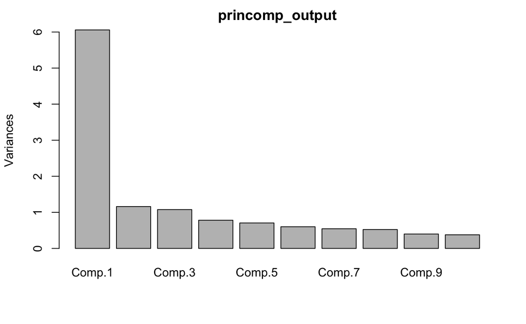

```r
## Print the scree plot

plot(princomp_output)
```

```r
summary(princomp_output)
```

```
Importance of components:
                          Comp.1     Comp.2     Comp.3     Comp.4     Comp.5     Comp.6     Comp.7     Comp.8    Comp.9    Comp.10
Standard deviation     2.4613684 1.07702795 1.03765022 0.88416948 0.84013084 0.77534434 0.73831512 0.72341731 0.6320162 0.61476362
Proportion of Variance 0.4660257 0.08922994 0.08282446 0.06013505 0.05429383 0.04624299 0.04193148 0.04025635 0.0307265 0.02907187
Cumulative Proportion  0.4660257 0.55525566 0.63808012 0.69821517 0.75250901 0.79875199 0.84068347 0.88093983 0.9116663 0.94073819
                          Comp.11    Comp.12   Comp.13
Standard deviation     0.52830849 0.50080344 0.4903973
Proportion of Variance 0.02146999 0.01929262 0.0184992
Cumulative Proportion  0.96220818 0.98150080 1.0000000
```

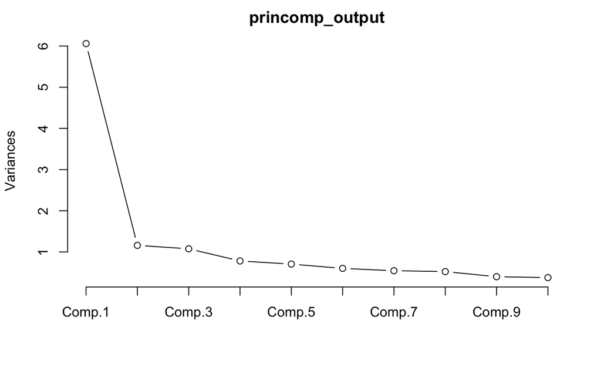

```r
plot(princomp_output,type="lines")
```